# Part II - (Prosper Loan Dataset Explanatory Project)

## by (Mayowa Shobande)

## Investigation Overview

> This is an explanatory analysis on Prosper Loan dataset. This presentation shows the result of the exploratory analysis performed on Prosper Loan dataset. In the analysis, features such as Borrowers Annual Percentage Rate, Borrowers Interest Rate, Borrowers Loan Status, Income range and Employment status were looked into to help predict borrowers loan outcomes over a period of time.

## Dataset Overview

> The data set contains 113,937 loans with 81 variables on each loan, including loan amount, borrower rate (or interest rate), current loan status, borrower income, and many others.

### Distribution of Borrowers Interest Rate

> Interest rates are highly distributed from points 0.05 to 0.3 as borrowers take loans with low interest rate.

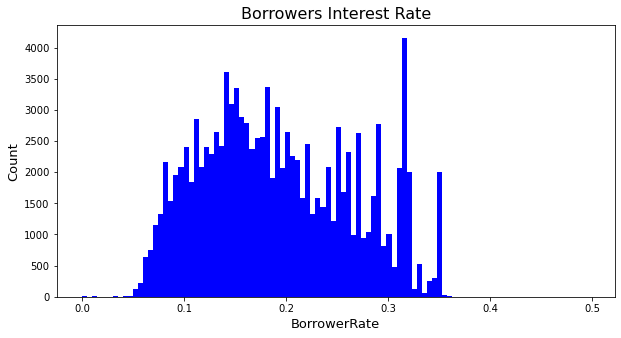

### Borrowers Loan Term

> The highest loan term is 60 months. Most approved loan term is 36 months.

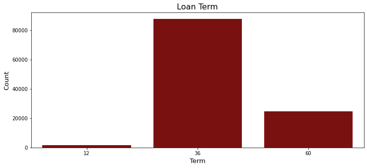

> Majority of borrowers have not completed repayment of loan.

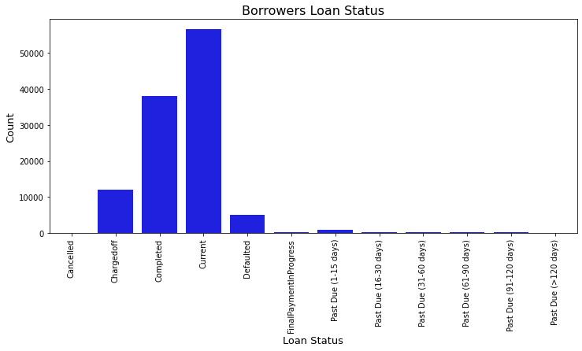

### Correlation Between Borrowers Annual Percentage Rate and Borrowers Interest Rate

There is high positive correlation between Borrowers Interest Rate and Borrowers Annual Percentage Rate.

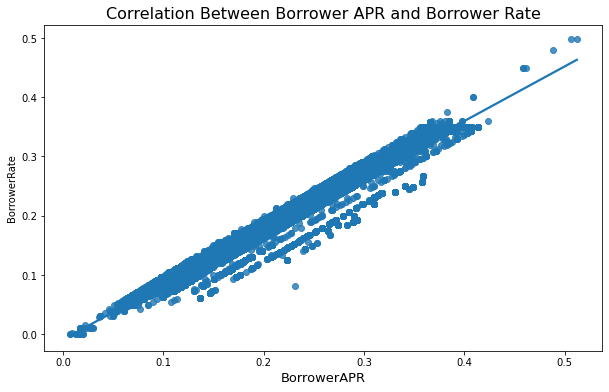

### Impact of Borrowers Income Range on Loan Investors

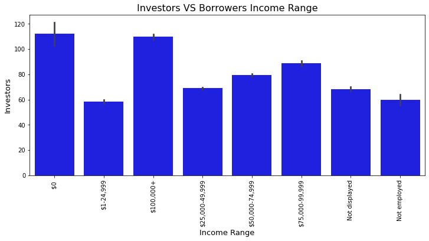

### Year VS Borrower Rate VS Loan Term

From 2005 till 2009, there was no information on borrowers interest for 12 months and 60 months loan term. Also, 36 months loan term is recorded as the common borrowers loan term over the years.

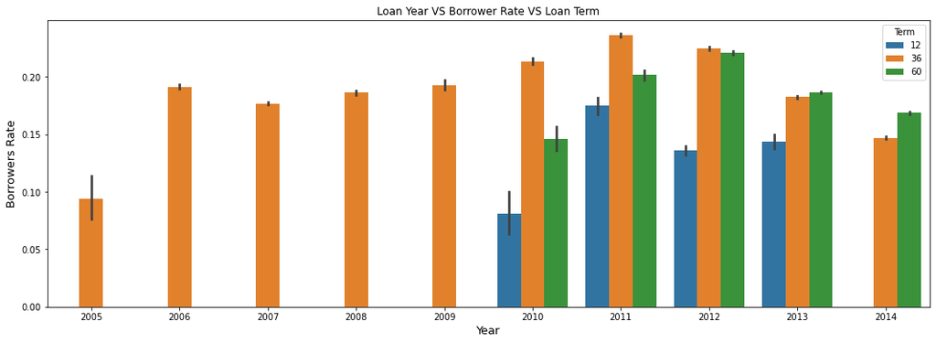

### Income Range VS Loan Original Amount VS Loan Term

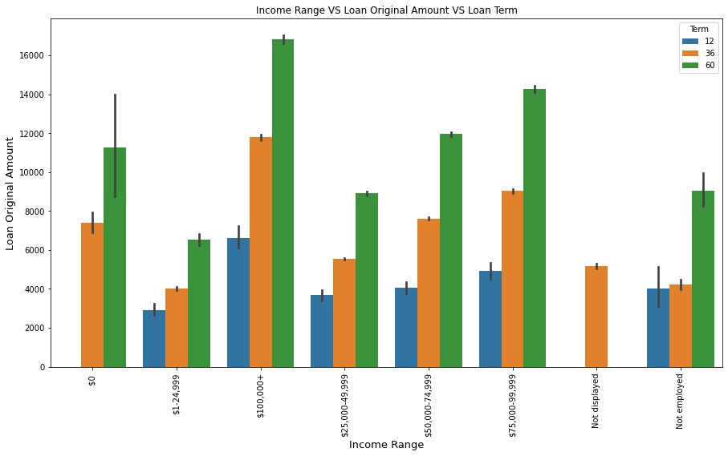